# Resumen laboratorios de Regresión Lineal

El siguiente documento es un resumen de los laboratorios que se encuentran en la sección de códigos de Blackboard y se han realizado en clase. En este documento se presenta de manera más ordenada la información de los laboratorios, pero tomar en cuenta que el objetivo de los mismos era hacerlo en clase en un contexto determinado, por lo que hay partes del documento que no son del todo autocontenidas y que quizás requieran para seguirlas los libros de texto, las diapositivas u otras referencias (apuntes, grabaciones, etc.)

# Laboratorio 1

Lo primero que debemos hacer **siempre** es cargar o instalar las librerías que necesitemos para nuestro trabajo.

En este curso hemos usado la librería `pacman`, la cual no solo carga la librería sino que la instala en caso que el usuario no la tenga instalada. Esto nos ahorra no solo los pasos de instalar y cargar, sino además instala la librería.

Verificamos si esta instalado la libreria `pacman`, en caso que no lo este, se instala

```r
if (! ('pacman' %in% installed.packages())) install.packages('pacman')
```

Una vez instalada la librería `pacman`, cargamos (o instalamos) las librerías necesarias para este laboratorio

```r
pacman::p_load("haven", "AER")
```

## Primer ejemplo del libro de Stock y Watson

### Dos formas de cargar los datos

La primera es accediendo a la web del libro y descargar los datos. Acceder a esta [dirección](https://wps.pearsoned.com/aw_stock_ie_3/178/45691/11696965.cw/index.html) y pinchar en *"Replication Files"* en el menu de la barra izquierda, luego pinchar en *"Datasets for Replicating Empirical Results (Original Edition)"*. Descargar los datos *"California Test Score Data Used in Chapters 4-9"* en formato STATA.

Vamos a practicar con el formato de STATA por dos motivos: debemos acostumbrarnos a trabajar con distintos formatos de datos mas alla del csv y xlsx, y porque STATA (de momento) sigue siendo el software estadístico predominante en organimos multilaterales y gubernamentales economicos, asi como en gran parte de la investigacion academica en economia

Una vez descargados los datos, lo leemos con la libreria haven

```r
caschool <- read_dta("Data/caschool.dta")
```

Vamos a replicar la regresion lineal del capitulo 4 trabajada en clase, la cual explicaba la calificación de la prueba de habilidad numerica y verbal en funcion del numero de alumnos por profesor

En R la funcion `lm()` lleva a cabo la regresion lineal, veamos la ayuda

```r
?lm
```

De momento nos concentramos en los primeros dos argumentos de la funcion, formula y data

```r
lm(data = caschool, formula = testscr ~ str)
```

```
##
## Call:
## lm(formula = testscr ~ str, data = caschool)
##
## Coefficients:
## (Intercept)          str
##      698.93        -2.28
```

Vemos que con el argumento data de la función `lm`, indicamos de que fuente de datos se deben obtener las variables, otra forma es no indicar dentro de la funcion la fuente de los datos, y usar la funcion `attach` previo a `lm`

```r
attach(caschool)
lm(testscr ~ str)
```

```
##
## Call:
## lm(formula = testscr ~ str)
##
## Coefficients:
## (Intercept)          str
##      698.93        -2.28
```

Asimismo, es deseable referenciar (asignar un nombre) el objeto que surge de la función `lm`

```r
estimacion_01 <- lm(testscr ~ str)
estimacion_01
```

```
##
## Call:
## lm(formula = testscr ~ str)
##
## Coefficients:
## (Intercept)          str
##      698.93        -2.28
```

Más adelante aprenderemos más acerca de la funcion `lm`

Para reproducir el gráfico del libro, usamos las funciones `plot` y `abline`

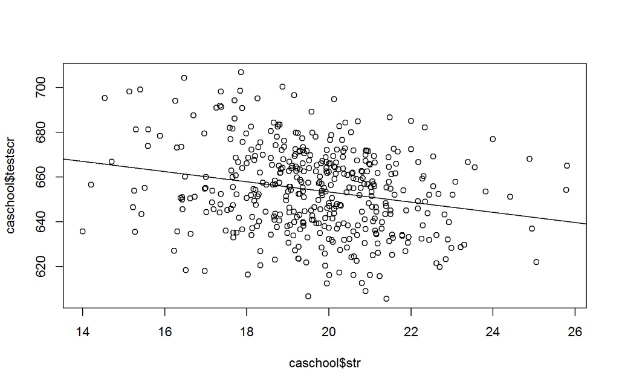

```r
plot(caschool$str, caschool$testscr)
abline(estimacion_01)
```

La función `abline` añade una línea recta a un gráfico, en este caso añade la línea que corresponde a los parámetros estimados por la función `lm` que hemos referenciado en `estimacion_01`

Mas parecido al gráfico del libro

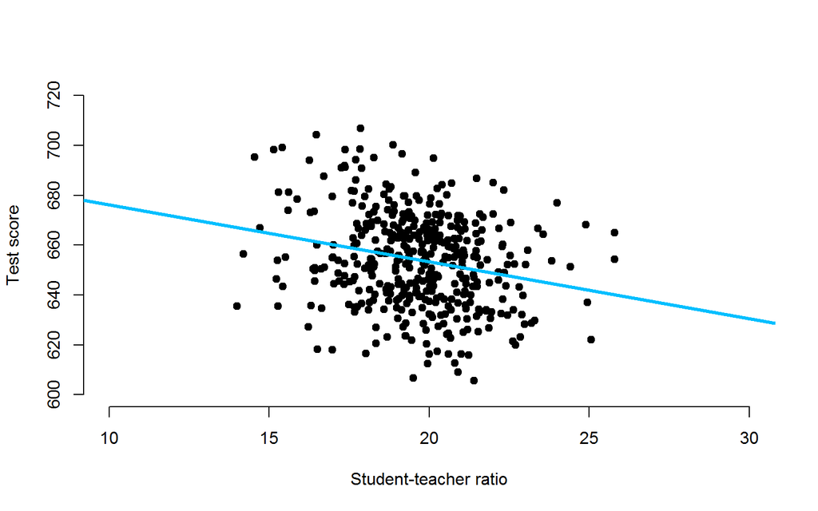

```r
plot(caschool$str, caschool$testscr,
     ylim = c(600,720),   #limites del eje y
     xlim = c(10,30),     #limites del eje x
     pch = 20,            #forma del simbolo (circulo)
     cex = 1.5,           #tamaño de la forma
     ylab = "Test score", #titulo del eje y
     xlab = "Student-teacher ratio", #titulo del eje x
     axes = FALSE)        #Sin ejes
axis(1) #eje x
axis(2) #eje y
abline(estimacion_01, col = "deepskyblue", lwd =3)
```

Si leen el documento de características de los datos, podran ver que las dos variables que hemos usado no estaban en los datos originales, sino que se han construido

Esto es algo que deben hacer continuamente en cualquier trabajo empirico, por lo que deberian practicarlo

Para esto, vamos a acceder los mismos datos de otra fuente, la libreraia AER (Applied Econometrics with R), accedamos al Vignette

```r
vignette("AER")
```

Veamos las bases de datos del libro de Stock y Watson (el resultado aparece en la pestaña de help)

```r
help("StockWatson2007", package = "AER")
```

```
## starting httpd help server ... done
```

Cargamos los datos

```r
data(CASchools)
```

Construimos las variables y estimamos el modelo

```r
CASchools$STR <- CASchools$students/CASchools$teachers

CASchools$Testscr <- (CASchools$math+CASchools$read)/2

lm(formula = Testscr ~ STR, data = CASchools)
```

```
##
## Call:
## lm(formula = Testscr ~ STR, data = CASchools)
##
## Coefficients:
## (Intercept)          STR
##      698.93        -2.28
```

## Regresion Lineal: Población vs muestra

El objetivo de la siguiente sección es replicar lo que ocurre si estimamos varias veces el mismo proceso, pero con distintas realizaciones del ruido. Aunque la analogía no es exacta, esto es algo similar a lo que ocurre si tomamos muestras repetidas de una población determinada, volveremos a esto en un próximo laboratorio. Ahora, lo que veremos, es que aún teniendo el modelo verdadero, el hecho de que exista un ruido en dicho modelo, hace que nuestras estimaciones sean solo una de muchas posibles

Vamos a replicar la figura 3.3 del libro [An Introduction to Statistical Learning](https://www.statlearning.com/)

Creamos la función del proceso generador de datos $Y=2+3x$

```r
x <- seq(-2, 2, length = 100)
y <- 2 + 3*x
```

A partir de 100 realizaciones de una normal con media cero y desviación típica (`dt`) 1, creamos el modelo $Y=f(x)+u$, donde $f(x)=2+3x$. Almacenamos los valores de $x$, $y$ y el nuevo $y$ estimado en un data frame `df`

```r
set.seed(1234)
dt <- 1
y_02 <- y + rnorm(n = 100, mean = 0, sd = dt)
df <- data.frame(x,y,y_02)
```

Estimamos el modelo a partir de los datos con ruido

```r
fit1 <- lm(formula = y_02 ~ x, data = df)
fit1
```

```
##
## Call:
## lm(formula = y_02 ~ x, data = df)
##
## Coefficients:
## (Intercept)            x
##       1.957        3.132
```

Repetimos el procedimiento anterior con 100 realizaciones distintas del error y estimamos los parámetros

```r
y_03 <- y + rnorm(n = 100, mean = 0, sd = dt)
df$y_03 <- y_03
fit2 <- lm(formula = y_03 ~ x, data = df)
fit2
```

```
##
## Call:
## lm(formula = y_03 ~ x, data = df)
##
## Coefficients:
## (Intercept)            x
##       2.147        3.122
```

Lo hacemos de nuevo

```r
y_04 <- y + rnorm(n = 100, mean = 0, sd = dt)
df$y_04 <- y_04
fit3 <- lm(formula = y_04 ~ x, data = df)
fit3
```

```
##
## Call:
## lm(formula = y_04 ~ x, data = df)
##
## Coefficients:
## (Intercept)            x
##       2.088        2.935
```

Observamos que las estimaciones de la ordenada en el origen y la pendiente cambian con distintas realizaciones del ruido

Graficamos el proceso generador de datos "real" con las estimaciones de la regresión lineal

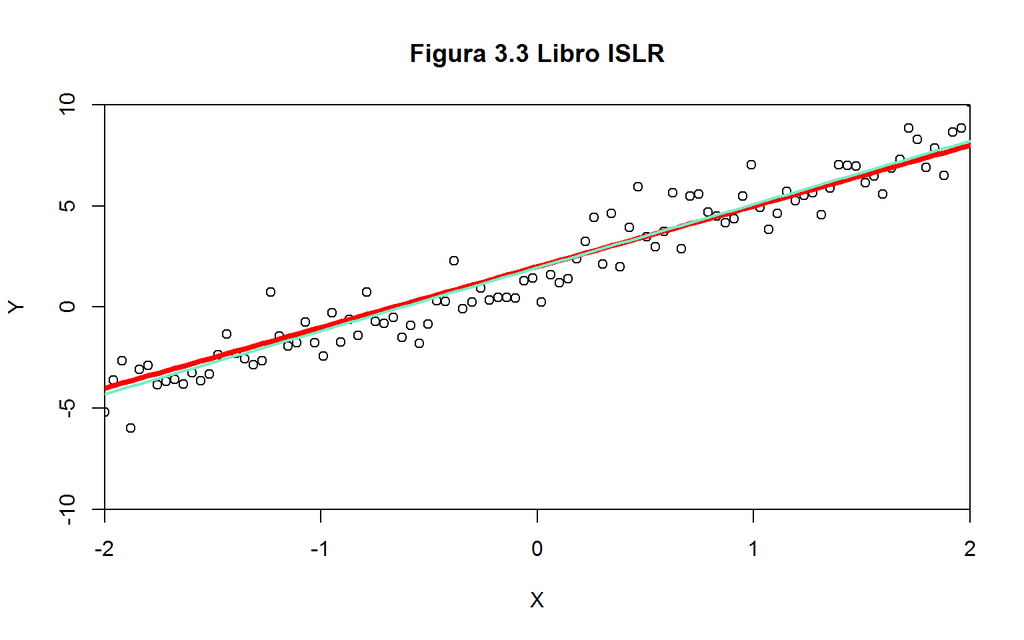

```r
plot(x,y_02,xlim=c(-2,2), ylim=c(-10,10), ylab = "Y", xlab = "X", yaxs="i", xaxs="i", main = "Figura 3.3 Libro ISLR")
lines(x,y, col="red", lwd=4)
lines(x, fitted(fit1), col=colors()[10*1], lwd=2)
```

Vamos a generar 10 nuevos modelos repitiendo lo anterior

Creamos un data frame vacio de 100 filas (x's) y 10 columnas (modelos), para rellenarlo luego con las distintas versiones del modelo

```r
df2 <- data.frame(matrix(, nrow=100, ncol=10))
```

Añadimos una columna con la variable X

```r
df2$x <- x
```

Generamos los 10 distintos conjuntos de datos a partir del proceso generador de datos y el ruido

Primero la columna Y

```r
for (i in 1:10) {
  df2[,i] <- y + rnorm(100, 0, dt)
}
```

Luego estimamos los 10 modelos y lo representamos graficamente

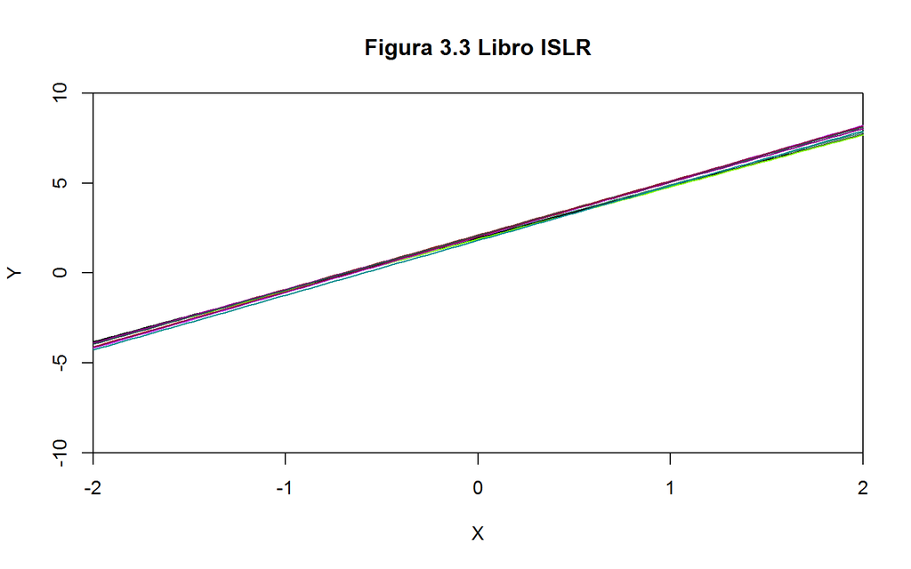

```r
plot(NULL, xlim=c(-2,2), ylim=c(-10,10), ylab = "Y", xlab = "X", yaxs="i", xaxs="i", main = "Figura 3.3 Libro ISLR")
for (i in 1:10) {
  fitt <- lm(data = df2, formula = df2[,i]~x)
  lines(x, fitted(fitt), col=colors()[12*i])
}
```

# Laboratorio 2

```r
pacman::p_load("haven", "wooldridge")
```

## Practica regresion lineal

**Nota:** parte de esta sección se desarrolla con más detalle en el html *Regresion Lineal Simple en R*

Volvemos al ejemplo del libro de Stock y Watson trabajado en la sección anterior

```r
caschool <- read_dta("Data/caschool.dta")

estimacion_01 <- lm(formula = testscr ~str, data = caschool)

summary(estimacion_01)
```

```
##
## Call:
## lm(formula = testscr ~ str, data = caschool)
##
## Residuals:
##     Min      1Q  Median      3Q     Max
## -47.727 -14.251   0.483  12.822  48.540
##
## Coefficients:
##             Estimate Std. Error t value Pr(>|t|)
## (Intercept) 698.9330     9.4675  73.825  < 2e-16 ***
## str          -2.2798     0.4798  -4.751 2.78e-06 ***
## ---
## Signif. codes:  0 '***' 0.001 '**' 0.01 '*' 0.05 '.' 0.1 ' ' 1
##
## Residual standard error: 18.58 on 418 degrees of freedom
## Multiple R-squared:  0.05124,    Adjusted R-squared:  0.04897
## F-statistic: 22.58 on 1 and 418 DF,  p-value: 2.783e-06
```

Accedemos a los coeficientes estimado del modelo

```r
estimacion_01$coefficients
```

```
## (Intercept)         str
##  698.932952   -2.279808
```

```r
estimacion_01$coefficients[1]
```

```
## (Intercept)
##     698.933
```

```r
estimacion_01$coefficients[2]
```

```
##       str
## -2.279808
```

```r
coef(estimacion_01)
```

```
## (Intercept)         str
##  698.932952   -2.279808
```

**Adicional: Regresión robusta** Esto se desarrolla con más detalle en el html *Regresión lineal simple con errores robustos a heterocedasticidad*

```r
pacman::p_load("lmtest", "sandwich")

coeftest(estimacion_01, vcov = vcovHC(estimacion_01, type = "HC1"))
```

```
##
## t test of coefficients:
##
##              Estimate Std. Error t value  Pr(>|t|)
## (Intercept) 698.93295   10.36436 67.4362 < 2.2e-16 ***
## str          -2.27981    0.51949 -4.3886 1.447e-05 ***
## ---
## Signif. codes:  0 '***' 0.001 '**' 0.01 '*' 0.05 '.' 0.1 ' ' 1
```

Accedemos a mas informacion ($R^2$, ESR), para esto accedemos a los atributos de la función `summary`

```r
attributes(summary(estimacion_01))
```

```
## $names
##  [1] "call"          "terms"         "residuals"     "coefficients"
##  [5] "aliased"       "sigma"         "df"            "r.squared"
##  [9] "adj.r.squared" "fstatistic"    "cov.unscaled"
##
## $class
## [1] "summary.lm"
```

```r
summary(estimacion_01)$r.squared
```

```
## [1] 0.0512401
```

```r
summary(estimacion_01)$sigma
```

```
## [1] 18.58097
```

Construimos los residuos

```r
bhat <- estimacion_01$coefficients
yhat <- estimacion_01$coefficients[1] + estimacion_01$coefficients[2]*caschool$str
residuo <- caschool$testscr - yhat
```

Lo representamos gráficamente para verificar que nuestros residuos estimados coinciden con los estimados por la función `lm`

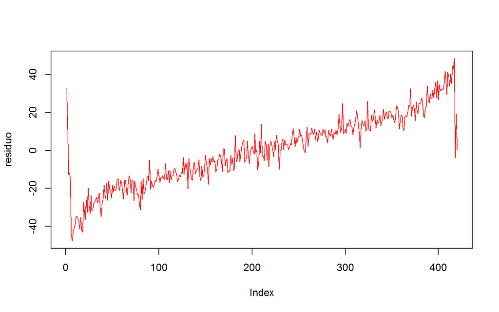

```r
plot(residuo, type = "l")
lines(estimacion_01$residuals, col="red")
```

Obtenemos las predicciones del modelo y los residuos, los organizamos en una tabla

```r
Str <-  caschool$str
Test_scr <-  caschool$testscr
testscr_hat <- estimacion_01$fitted.values
u_hat <- estimacion_01$residuals
```

Donde `Test_scr` es el valor observado de las calificaciones de la prueba de aptitud, y `testscr_hat` es la estimación de las calificaciones del modelo. El residuo `u_hat` es la diferencia entre ambas.

Usamos el comando `cbind()` para unir las columnas (vectores) de datos que hemos creado en el paso anterior

```r
tabla01 <- cbind(Str, Test_scr, testscr_hat, u_hat)

head(tabla01)
```

```
##        Str Test_scr testscr_hat     u_hat
## 1 17.88991   690.80    658.1474  32.65260
## 2 21.52466   661.20    649.8608  11.33917
## 3 18.69723   643.60    656.3069 -12.70689
## 4 17.35714   647.70    659.3620 -11.66198
## 5 18.67133   640.85    656.3659 -15.51593
## 6 21.40625   605.55    650.1308 -44.58076
```

A continuación, replicamos algunos de los ejemplos del libro de Wooldridge

### Ejemplo 2.3 libro Wooldridge

```r
data(ceosal1)

estimacion_wool01 <- lm(formula = salary ~roe, data = ceosal1)
estimacion_wool01
```

```
##
## Call:
## lm(formula = salary ~ roe, data = ceosal1)
##
## Coefficients:
## (Intercept)          roe
##       963.2         18.5
```

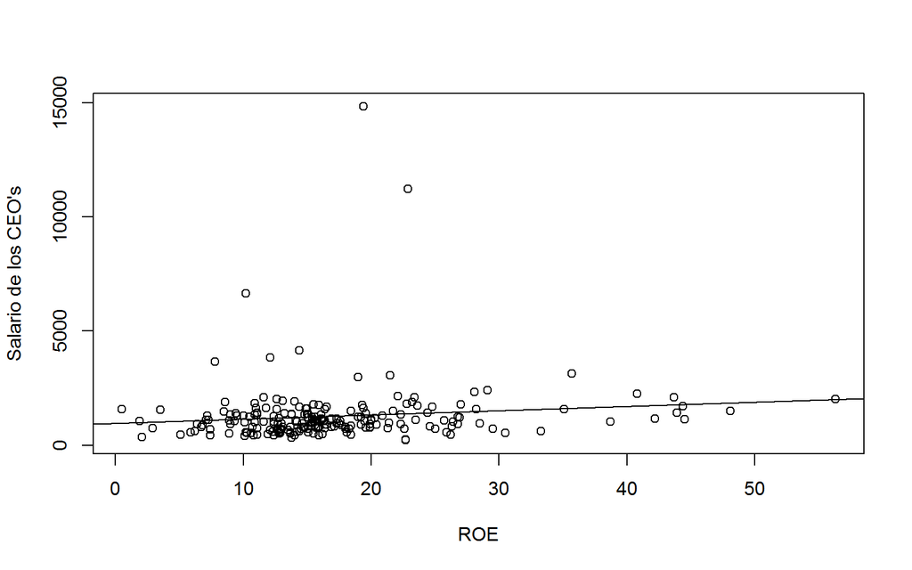

```r
plot(ceosal1$roe, ceosal1$salary, xlab = "ROE", ylab = "Salario de los CEO's")
abline(estimacion_wool01)
```

Los siguientes dos ejemplos deben completarlos siguiendo el paso anterior

### Ejemplo 2.4 libro Wooldridge: Relacion entre salario (wage) y educacion (educ) (Tarea: inspeccionar los datos)

```r
data("wage1")

estimacion_wool02 <- lm()
estimacion_wool02

plot(, xlab = , ylab = )
abline(estimacion_wool02)
```

### Ejemplo 2.5 libro Wooldridge: Relacion entre resultado de las elecciones (voteA) y el gasto en la campaña electoral (shareA)

```r
data("vote1")

?vote1
```

## Distribucion muestral de los betas

Al igual que en su curso pasado de estadística inferencial, en el cual se estimaba un parámetro poblacional desconocido a partir de una muestra usando un estadístico, en este caso hacemos lo mismo cuando estimamos los parámetros de un modelo lineal.

Del mismo modo que podíamos construir una distribución de estadísticos muestrales, partiendo del supuesto de que tomabamos muestras repetidas de una población dada, podemos crear una distribución de los betas estimados en un modelo lineal.

A continuación vamos a tomar sub-muestras de las base de datos de caschool, y estimamos el modelo lineal $Testscr=\beta_0+\beta_1STR+u$ en cada una de ellas

Comenzamos creando un vector vacio de betas, cuya dimesión es igual al número de sub-muestras (y veces que estimamos el modelo) que tomamos

```r
beta_1 <- vector(length = 1000)
```

Para tomar una muestra (en este caso de tamaño 100) de un data frame, hacemos lo siguiente

```r
sample(nrow(caschool),100)
```

```
##   [1] 363 409 264  63 224 350 368 319  69 267  82   1 164 166 142 378 369 263
##  [19] 355 323 330 331 318 158  46 149 364 218 160 348 116 191  29 248 253 150
##  [37]  37 308 201 246 418 216 301 196  62 416 232  66 108 271 414 208 152   9
##  [55] 254 395 380 145 313 357  16  31 413 278 383 406 339  56 180 412 307 255
##  [73]  80 133 256  47  25  97 206 157 175 361 302 137 375 136 210 184 203 371
##  [91] 294 386 124 154 229 411  54  20 362 396
```

```r
caschool[sample(nrow(caschool),100), ]
```

```
## # A tibble: 100 x 18
##    observat dist_cod county district gr_span enrl_tot teachers calw_pct meal_pct
##       <dbl>    <dbl> <chr>  <chr>    <chr>      <dbl>    <dbl>    <dbl>    <dbl>
##  1      291    69815 Santa~ Santa C~ KK-06       3005    159.     8.62     33.8
##  2       82    62539 Fresno West Pa~ KK-08        314     19.2   29.9      93.6
##  3      280    66795 Placer Colfax ~ KK-08        507     26.6   13.2      37.1
##  4       58    67421 Sacra~ Robla E~ KK-06       2253    113.    43.5      84.6
##  5      318    67967 San D~ Alpine ~ KK-08       2272    109.     4.05     16.1
##  6      278    63750 Kern   Rosedal~ KK-08       3548    171.     3.26     14.9
##  7      146    68205 San D~ Lemon G~ KK-08       4612    233.    17.5      65.9
##  8       59    66191 Monte~ Santa R~ KK-08       2807    126.    15.5      52.4
##  9      106    67470 San B~ Hollist~ KK-08       5718    295.     6.84     37.0
## 10      388    69104 Santa~ Ballard~ KK-06        134      6      0.746     3.73
## # ... with 90 more rows, and 9 more variables: computer <dbl>, testscr <dbl>,
## #   comp_stu <dbl>, expn_stu <dbl>, str <dbl>, avginc <dbl>, el_pct <dbl>,
## #   read_scr <dbl>, math_scr <dbl>
```

Rellenamos el vector con los betas estimados tomando solo una muestra de los datos originales

```r
for (i in seq_along(beta_1)) {
  estima <- lm(data =  caschool[sample(nrow(caschool),100),], formula = testscr ~str)
  beta_1[i] <- estima$coefficients[2]
}

mean(beta_1)
```

```
## [1] -2.307918
```

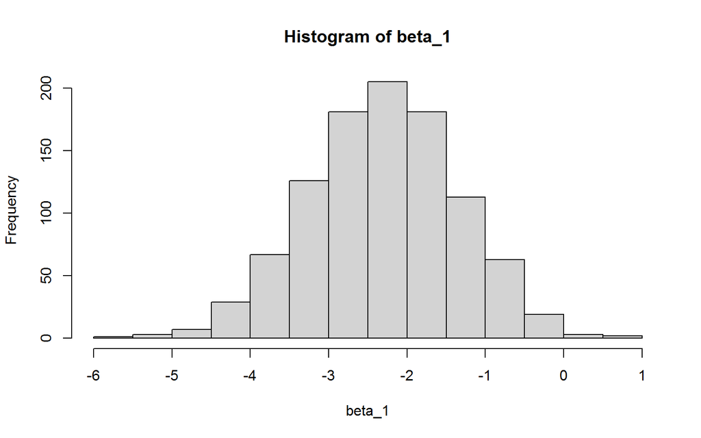

```r
hist(beta_1)
```

**NOTA DE R**: En lugar de la función `seq_along`se puede usar una notación más convencional en otros lenguajes como `for (i in 1..1000)` o `for (i in 1:1000)` o `for i in range(1000)`, que significa "repite esta operación en índices que van del 1 al 1000 en saltos de 1" que es una manera sofisticada de decir "repite esta operación 1000 veces"

**NOTA DE R**: En lugar de usar un bucle se puede usar la función `replicate`, una de las funciones de la familia `apply`, las cuales aplican una función a un vector de valores, que es lo mismo que hace un bucle cuando *aplica* de manera repetida la misma operación a un conjunto de valores representado por un vector. En este caso estamos haciendo algo más sencillo, repetir un número de veces una instrucción encapsulada en una función, en este caso que nos extraiga de manera repetida una muestra de una población y calcule una regresion. Así que `replicate` en nuestro ejemplo repite 1000 veces la operación descrita arriba.

Este tipo de operaciones se realiza muchas veces en estadística, ya que de esa manera hacemos *simulaciones*, repetir muchas veces realizaciones de una distribución de probabilidad o un fenómeno cuyo resultado sea incierto (lanzar un dado 50000 veces)

```r
betas_1_2 <- replicate(expr = lm(data =  caschool[sample(nrow(caschool),100),], formula = testscr ~str)$coefficients[2],
                          n = 1000)

mean(betas_1_2)
```

```
## [1] -2.365471
```

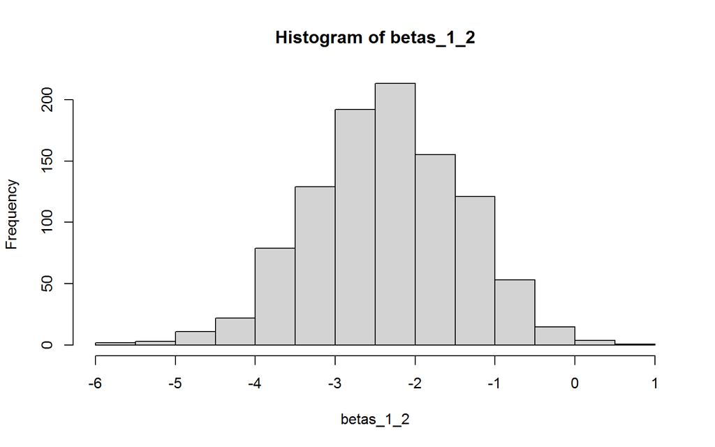

```r
hist(betas_1_2)
```

# Laboratorio 3

```r
pacman::p_load("haven", "wooldridge")
```

## Regresion lineal: parámetros

**Nota:** parte de esta sección se desarrolla con más detalle en el html *Regresion Lineal Simple en R*

Volvemos al ejemplo del libro de Stock y Watson trabajado en las secciones anteriores

```r
caschool <- read_dta("Data/caschool.dta")

estimacion_01 <- lm(formula = testscr ~str, data = caschool)

summary(estimacion_01)
```

```
##
## Call:
## lm(formula = testscr ~ str, data = caschool)
##
## Residuals:
##     Min      1Q  Median      3Q     Max
## -47.727 -14.251   0.483  12.822  48.540
##
## Coefficients:
##             Estimate Std. Error t value Pr(>|t|)
## (Intercept) 698.9330     9.4675  73.825  < 2e-16 ***
## str          -2.2798     0.4798  -4.751 2.78e-06 ***
## ---
## Signif. codes:  0 '***' 0.001 '**' 0.01 '*' 0.05 '.' 0.1 ' ' 1
##
## Residual standard error: 18.58 on 418 degrees of freedom
## Multiple R-squared:  0.05124,    Adjusted R-squared:  0.04897
## F-statistic: 22.58 on 1 and 418 DF,  p-value: 2.783e-06
```

Ya sabemos como acceder a los betas, el ESR y el $R^2$. Ahora vamos a acceder a los errores estándar de los parámetros, el t-valor y el p-valor

Volvemos a los atributos de la función `summary`

```r
attributes(summary(estimacion_01))
```

```
## $names
##  [1] "call"          "terms"         "residuals"     "coefficients"
##  [5] "aliased"       "sigma"         "df"            "r.squared"
##  [9] "adj.r.squared" "fstatistic"    "cov.unscaled"
##
## $class
## [1] "summary.lm"
```

Inspeccionamos el atributo coefficients

```r
summary(estimacion_01)$coefficients
```

```
##               Estimate Std. Error   t value      Pr(>|t|)
## (Intercept) 698.932952  9.4674914 73.824514 6.569925e-242
## str          -2.279808  0.4798256 -4.751327  2.783307e-06
```

Podemos ver que es una matriz de dimension 2,4

```r
class(summary(estimacion_01)$coefficients)
```

```
## [1] "matrix" "array"
```

```r
dim(summary(estimacion_01)$coefficients)
```

```
## [1] 2 4
```

Sabiendo esto, podemos extraer los elementos deseados

Error estándar de $\beta_0$

```r
summary(estimacion_01)$coefficients[1,2]
```

```
## [1] 9.467491
```

Error estándar de $\beta_1$

```r
summary(estimacion_01)$coefficients[2,2]
```

```
## [1] 0.4798256
```

Estadístico t para contrastar que $\beta_1$ es 0

```r
summary(estimacion_01)$coefficients[2,3]
```

```
## [1] -4.751327
```

p-valor del contraste de $\beta_1$

```r
summary(estimacion_01)$coefficients[2,4]
```

```
## [1] 2.783307e-06
```

**NOTA**: Si desea comparar el estadístico t con el valor critico, lo puede hacer con la funcion `qt()`

```r
qt(p = 0.995, df = 418)
```

```
## [1] 2.587642
```

Una manera de comapararlo

```r
t_valor <- summary(estimacion_01)$coefficients[2,3]
contraste <- qt(p = 0.995, df = 418)
ifelse(abs(t_valor)>abs(contraste),"Rechaza","Acepta")
```

```
## [1] "Rechaza"
```

Intervalos de confianza para $\beta_1$

```r
confint(estimacion_01)
```

```
##                 2.5 %     97.5 %
## (Intercept) 680.32313 717.542779
## str          -3.22298  -1.336637
```

Tambien se podria calcular "manualmente" lo anterior. Para eso, necesitariamos el numero de observaciones

```r
n <- nobs(estimacion_01)
n
```

```
## [1] 420
```

# Laboratorio 4

```r
pacman::p_load("haven", "wooldridge")
```

## Regresion lineal multiple: motivación

Volvemos al ejemplo del libro de Stock y Watson trabajado en las secciones anteriores, y añadimos una variable adicional, el nivel de ingreso promedio del distrito escolar

```r
caschool <- read_dta("Data/caschool.dta")

modelo_cas01 <- lm(data = caschool, testscr ~ str)
summary(modelo_cas01)
```

```
##
## Call:
## lm(formula = testscr ~ str, data = caschool)
##
## Residuals:
##     Min      1Q  Median      3Q     Max
## -47.727 -14.251   0.483  12.822  48.540
##
## Coefficients:
##             Estimate Std. Error t value Pr(>|t|)
## (Intercept) 698.9330     9.4675  73.825  < 2e-16 ***
## str          -2.2798     0.4798  -4.751 2.78e-06 ***
## ---
## Signif. codes:  0 '***' 0.001 '**' 0.01 '*' 0.05 '.' 0.1 ' ' 1
##
## Residual standard error: 18.58 on 418 degrees of freedom
## Multiple R-squared:  0.05124,    Adjusted R-squared:  0.04897
## F-statistic: 22.58 on 1 and 418 DF,  p-value: 2.783e-06
```

```r
modelo_cas02 <- lm(data = caschool, testscr ~ str + avginc)
summary(modelo_cas02)
```

```
##
## Call:
## lm(formula = testscr ~ str + avginc, data = caschool)
##
## Residuals:
##     Min      1Q  Median      3Q     Max
## -39.608  -9.052   0.707   9.259  31.898
##
## Coefficients:
##              Estimate Std. Error t value Pr(>|t|)
## (Intercept) 638.72915    7.44908  85.746   <2e-16 ***
## str          -0.64874    0.35440  -1.831   0.0679 .
## avginc        1.83911    0.09279  19.821   <2e-16 ***
## ---
## Signif. codes:  0 '***' 0.001 '**' 0.01 '*' 0.05 '.' 0.1 ' ' 1
##
## Residual standard error: 13.35 on 417 degrees of freedom
## Multiple R-squared:  0.5115, Adjusted R-squared:  0.5091
## F-statistic: 218.3 on 2 and 417 DF,  p-value: < 2.2e-16
```

Vemos como al añadir un nuevo regresor cambia el valor del parámetro $\beta_1$ que denota el efecto de *STR* sobre la calificación del examen

## Ejemplo 3.2 libro Wooldridge pag. 76 (salario real por hora)

526 observaciones sobre trabajadores en la base de datos WAGE1, las variables educ (años de educación), exper (años de experiencia en el mercado laboral) y tenure (años de antigüedad en el empleo actual) se incluyen en una ecuación para explicar log(wage)

```r
data("wage1")

estimacion_wage <- lm(data = wage1, log(wage) ~ educ + exper + tenure)
summary(estimacion_wage)
```

```
##
## Call:
## lm(formula = log(wage) ~ educ + exper + tenure, data = wage1)
##
## Residuals:
##      Min       1Q   Median       3Q      Max
## -2.05802 -0.29645 -0.03265  0.28788  1.42809
##
## Coefficients:
##             Estimate Std. Error t value Pr(>|t|)
## (Intercept) 0.284360   0.104190   2.729  0.00656 **
## educ        0.092029   0.007330  12.555  < 2e-16 ***
## exper       0.004121   0.001723   2.391  0.01714 *
## tenure      0.022067   0.003094   7.133 3.29e-12 ***
## ---
## Signif. codes:  0 '***' 0.001 '**' 0.01 '*' 0.05 '.' 0.1 ' ' 1
##
## Residual standard error: 0.4409 on 522 degrees of freedom
## Multiple R-squared:  0.316,  Adjusted R-squared:  0.3121
## F-statistic: 80.39 on 3 and 522 DF,  p-value: < 2.2e-16
```

Estadistico de contraste

```r
qt(p = 0.975, df = 522)
```

```
## [1] 1.964519
```

p-valor

```r
pt(2.391, df = 522, lower.tail = FALSE)*2
```

```
## [1] 0.01715581
```

## Regresión lineal multiple en notacion matricial

Ejemplo sacado de este [libro](http://www.urfie.net/downloads03.html) (sería interesante revisar este libro para replicar en R los ejemplos del libro de Wooldridge)

Las diapositivas hacen refererencia a la presentación de clase *"Regresión lineal múltiple: estimación"*

```r
data(gpa1)
```

Tamaño de la muestra y numero de regresores

```r
n <- nrow(gpa1)
k <- 2
```

```r
y <- gpa1$colGPA
```

Construimos la matriz de regresores $X$ (en este caso 2) y añadimos una columna de unos (ver diapositiva 10)

```r
X <- cbind(1, gpa1$hsGPA, gpa1$ACT)
```

Inspeccionamos las primeras filas de $X$:

```r
head(X)
```

```
##      [,1] [,2] [,3]
## [1,]    1  3.0   21
## [2,]    1  3.2   24
## [3,]    1  3.6   26
## [4,]    1  3.5   27
## [5,]    1  3.9   28
## [6,]    1  3.4   25
```

Estimamos los betas usando la expresión de la diapositiva 19:
$$\hat{\beta}=(X'X)^{-1}X'y$$

```r
beta_hat <- solve( t(X)%*%X ) %*% t(X)%*%y
beta_hat
```

```
##             [,1]
## [1,] 1.286327767
## [2,] 0.453455885
## [3,] 0.009426012
```

El comando `solve` invierte la matriz, y la función `t()` ejecuta la transpuesta de una matriz y el operador `%*%` realiza productos de matrices, por lo que `solve( t(X)%*%X )` ejecuta la operación $(X'X)^{-1}$

Calculamos los residuos

```r
uhat <- y - X %*% beta_hat
```

Calculamos la varianza estimada de $u$ y el ESR, de la diapositiva 30:

$$\sigma^2=\frac{\sum\hat{u^2_i}}{n-k-1}=\frac{u'u}{n-k-1}$$

Nota: en la presentación de clase se usa $\epsilon$ en lugar de $u$

```r
sigsqhat <- as.numeric( t(uhat) %*% uhat / (n-k-1) )
ESR <- sqrt(sigsqhat)
sigsqhat
```

```
## [1] 0.1158148
```

```r
ESR
```

```
## [1] 0.3403158
```

Varianza estimada de los betas (matriz de varianzas y covarianzas $MVC(\hat{\beta})$) y su error estándar. En la diapositiva 30 podrá encontrar la expresión:

$$MVC(\hat{\beta})=\hat{\sigma^2}(X'X)^{-1}$$

```r
Vbetahat <- sigsqhat * solve( t(X)%*%X )
Vbetahat
```

```
##              [,1]          [,2]          [,3]
## [1,]  0.116159717 -0.0226063687 -0.0015908486
## [2,] -0.022606369  0.0091801149 -0.0003570767
## [3,] -0.001590849 -0.0003570767  0.0001161478
```

```r
seBeta_hat <- sqrt( diag(Vbetahat))
seBeta_hat
```

```
## [1] 0.34082212 0.09581292 0.01077719
```

Verificamos los valores con los resultados de la estimación usando `lm`

```r
modelo_gpa01 <- lm(data = gpa1, formula = colGPA ~ hsGPA + ACT )
summary(modelo_gpa01)
```

```
##
## Call:
## lm(formula = colGPA ~ hsGPA + ACT, data = gpa1)
##
## Residuals:
##      Min       1Q   Median       3Q      Max
## -0.85442 -0.24666 -0.02614  0.28127  0.85357
##
## Coefficients:
##             Estimate Std. Error t value Pr(>|t|)
## (Intercept) 1.286328   0.340822   3.774 0.000238 ***
## hsGPA       0.453456   0.095813   4.733 5.42e-06 ***
## ACT         0.009426   0.010777   0.875 0.383297
## ---
## Signif. codes:  0 '***' 0.001 '**' 0.01 '*' 0.05 '.' 0.1 ' ' 1
##
## Residual standard error: 0.3403 on 138 degrees of freedom
## Multiple R-squared:  0.1764, Adjusted R-squared:  0.1645
## F-statistic: 14.78 on 2 and 138 DF,  p-value: 1.526e-06
```

# Laboratorio 5

El objetivo de este laboratorio es aprender el uso de la función `summ`de la librería `jtools`, que aporta un resumen de la estimación del modelo visualmente más agradable y parecida a los resumenes que se suelen encontrar en publicaciones académicas e informes corporativos.

Cargamos las librerías

```r
pacman::p_load(haven, jtools, vtable, huxtable)
```

Usamos el ejemplo del libro de Stock y Watson con el cual buscan motivar la regresión lineal multiple. Cargamos los datos y vemos como con la función `vtable` podemos ver un resumen de las variables del data frame

```r
caschool <- read_dta("Data/caschool.dta")

vtable(caschool)
```

caschool

| Name | Class | Values |
| --- | --- | --- |
| observat | numeric | Num: 1 to 420 |
| dist_cod | numeric | Num: 61382 to 75440 |
| county | character |  |
| district | character |  |
| gr_span | character |  |
| enrl_tot | numeric | Num: 81 to 27176 |
| teachers | numeric | Num: 4.85 to 1429 |
| calw_pct | numeric | Num: 0 to 78.994 |
| meal_pct | numeric | Num: 0 to 100 |
| computer | numeric | Num: 0 to 3324 |
| testscr | numeric | Num: 605.55 to 706.75 |
| comp_stu | numeric | Num: 0 to 0.421 |
| expn_stu | numeric | Num: 3926.07 to 7711.507 |
| str | numeric | Num: 14 to 25.8 |
| avginc | numeric | Num: 5.335 to 55.328 |
| el_pct | numeric | Num: 0 to 85.54 |
| read_scr | numeric | Num: 604.5 to 704 |
| math_scr | numeric | Num: 605.4 to 709.5 |

Estimamos el modelo

```r
modelo_cas01 <- lm(data = caschool, testscr ~ str)
summary(modelo_cas01)
```

```
##
## Call:
## lm(formula = testscr ~ str, data = caschool)
##
## Residuals:
##     Min      1Q  Median      3Q     Max
## -47.727 -14.251   0.483  12.822  48.540
##
## Coefficients:
##             Estimate Std. Error t value Pr(>|t|)
## (Intercept) 698.9330     9.4675  73.825  < 2e-16 ***
## str          -2.2798     0.4798  -4.751 2.78e-06 ***
## ---
## Signif. codes:  0 '***' 0.001 '**' 0.01 '*' 0.05 '.' 0.1 ' ' 1
##
## Residual standard error: 18.58 on 418 degrees of freedom
## Multiple R-squared:  0.05124,    Adjusted R-squared:  0.04897
## F-statistic: 22.58 on 1 and 418 DF,  p-value: 2.783e-06
```

En lugar de usa summary, vamos a usar la funcion `summ` de la libreria `jtools`

```r
summ(modelo_cas01)
```

| Observations | 420 |
| --- | --- |
| Dependent variable | testscr |
| Type | OLS linear regression |

| F(1,418) | 22.58 |
| --- | --- |
| R² | 0.05 |
| Adj. R² | 0.05 |

|  | Est. | S.E. | t val. | p |
| --- | --- | --- | --- | --- |
| (Intercept) | 698.93 | 9.47 | 73.82 | 0.00 |
| str | -2.28 | 0.48 | -4.75 | 0.00 |

Standard errors: OLS

Si deseamos estimaciones robustas de los errores estándar, lo indicamos con el argumento `robust`

```r
summ(modelo_cas01, robust = "HC1")
```

| Observations | 420 |
| --- | --- |
| Dependent variable | testscr |
| Type | OLS linear regression |

| F(1,418) | 22.58 |
| --- | --- |
| R² | 0.05 |
| Adj. R² | 0.05 |

|  | Est. | S.E. | t val. | p |
| --- | --- | --- | --- | --- |
| (Intercept) | 698.93 | 10.36 | 67.44 | 0.00 |
| str | -2.28 | 0.52 | -4.39 | 0.00 |

Standard errors: Robust, type = HC1

Siguiendo el ejemplo del libro, vamos a introducir una nueva variable, el porcentaje de estudiantes que son estudiantes de inglés (es decir, estudiantes para quienes el inglés es un segundo idioma)

```r
modelo_cas03 <- lm(data = caschool, testscr ~ str + el_pct)
summ(modelo_cas03)
```

| Observations | 420 |
| --- | --- |
| Dependent variable | testscr |
| Type | OLS linear regression |

| F(2,417) | 155.01 |
| --- | --- |
| R² | 0.43 |
| Adj. R² | 0.42 |

|  | Est. | S.E. | t val. | p |
| --- | --- | --- | --- | --- |
| (Intercept) | 686.03 | 7.41 | 92.57 | 0.00 |
| str | -1.10 | 0.38 | -2.90 | 0.00 |
| el_pct | -0.65 | 0.04 | -16.52 | 0.00 |

Standard errors: OLS

Vamos a usar errores robustos a heterocedasticidad, para que los resultados sean comparables a los del libro

```r
summ(modelo_cas03, robust = "HC1")
```

| Observations | 420 |
| --- | --- |
| Dependent variable | testscr |
| Type | OLS linear regression |

| F(2,417) | 155.01 |
| --- | --- |
| R² | 0.43 |
| Adj. R² | 0.42 |

|  | Est. | S.E. | t val. | p |
| --- | --- | --- | --- | --- |
| (Intercept) | 686.03 | 8.73 | 78.60 | 0.00 |
| str | -1.10 | 0.43 | -2.54 | 0.01 |
| el_pct | -0.65 | 0.03 | -20.94 | 0.00 |

Standard errors: Robust, type = HC1

Incluimos el intervalo de confianza en la salida de la estimacion

```r
summ(modelo_cas03, robust = "HC1", confint = TRUE)
```

| Observations | 420 |
| --- | --- |
| Dependent variable | testscr |
| Type | OLS linear regression |

| F(2,417) | 155.01 |
| --- | --- |
| R² | 0.43 |
| Adj. R² | 0.42 |

|  | Est. | 2.5% | 97.5% | t val. | p |
| --- | --- | --- | --- | --- | --- |
| (Intercept) | 686.03 | 668.88 | 703.19 | 78.60 | 0.00 |
| str | -1.10 | -1.95 | -0.25 | -2.54 | 0.01 |
| el_pct | -0.65 | -0.71 | -0.59 | -20.94 | 0.00 |

Standard errors: Robust, type = HC1

Si se desea incluir mas decimales lo hacemos con el argumento `digits`

```r
summ(modelo_cas03, robust = "HC1", confint = TRUE, digits = 3)
```

| Observations | 420 |
| --- | --- |
| Dependent variable | testscr |
| Type | OLS linear regression |

| F(2,417) | 155.014 |
| --- | --- |
| R² | 0.426 |
| Adj. R² | 0.424 |

|  | Est. | 2.5% | 97.5% | t val. | p |
| --- | --- | --- | --- | --- | --- |
| (Intercept) | 686.032 | 668.875 | 703.189 | 78.599 | 0.000 |
| str | -1.101 | -1.952 | -0.250 | -2.544 | 0.011 |
| el_pct | -0.650 | -0.711 | -0.589 | -20.939 | 0.000 |

Standard errors: Robust, type = HC1

Otra manera de presentar el resumen de la estimación con la función `export_summs`

```r
export_summs(modelo_cas03)
```

|  | Model 1 |
| --- | --- |
| (Intercept) | 686.03 *** |
|  | (7.41) |
| str | -1.10 ** |
|  | (0.38) |
| el_pct | -0.65 *** |
|  | (0.04) |
| N | 420 |
| R2 | 0.43 |
| *** p < 0.001; ** p < 0.01; * p < 0.05. |  |

Con errores robustos

```r
export_summs(modelo_cas03, robust="HC1")
```

|  | Model 1 |
| --- | --- |
| (Intercept) | 686.03 *** |
|  | (8.73) |
| str | -1.10 * |
|  | (0.43) |
| el_pct | -0.65 *** |
|  | (0.03) |
| N | 420 |
| R2 | 0.43 |
| Standard errors are heteroskedasticity robust. *** p < 0.001; ** p < 0.01; * p < 0.05. |  |

Este formato es util si deseamos comparar modelos

```r
export_summs(modelo_cas01, modelo_cas03, robust=TRUE)
```

|  | Model 1 | Model 2 |
| --- | --- | --- |
| (Intercept) | 698.93 *** | 686.03 *** |
|  | (10.46) | (8.81) |
| str | -2.28 *** | -1.10 * |
|  | (0.52) | (0.44) |
| el_pct |  | -0.65 *** |
|  |  | (0.03) |
| N | 420 | 420 |
| R2 | 0.05 | 0.43 |
| Standard errors are heteroskedasticity robust. *** p < 0.001; ** p < 0.01; * p < 0.05. |  |  |

También podemos asignar nombres a las variables, asi se entiende mejor la estimaciòn al presentarla a un tercero

```r
export_summs(modelo_cas01, modelo_cas03,
             robust="HC1",
             coefs = c("Intercepto" = "(Intercept)",
                       "Alumnos por profesor" = "str",
                       "% de estudiantes de inglés" = "el_pct")
             )
```

|  | Model 1 | Model 2 |
| --- | --- | --- |
| Intercepto | 698.93 *** | 686.03 *** |
|  | (10.36) | (8.73) |
| Alumnos por profesor | -2.28 *** | -1.10 * |
|  | (0.52) | (0.43) |
| % de estudiantes de inglés |  | -0.65 *** |
|  |  | (0.03) |
| N | 420 | 420 |
| R2 | 0.05 | 0.43 |
| Standard errors are heteroskedasticity robust. *** p < 0.001; ** p < 0.01; * p < 0.05. |  |  |

Y cambiar el nombre de los modelos

```r
export_summs(modelo_cas01, modelo_cas03,
             robust="HC1",
             coefs = c("Intercepto" = "(Intercept)",
                       "Alumnos por profesor" = "str",
                       "% de estudiantes de inglés" = "el_pct"),
             model.names = c("Modelo 1", "Modelo 2")
            )
```

|  | Modelo 1 | Modelo 2 |
| --- | --- | --- |
| Intercepto | 698.93 *** | 686.03 *** |
|  | (10.36) | (8.73) |
| Alumnos por profesor | -2.28 *** | -1.10 * |
|  | (0.52) | (0.43) |
| % de estudiantes de inglés |  | -0.65 *** |
|  |  | (0.03) |
| N | 420 | 420 |
| R2 | 0.05 | 0.43 |
| Standard errors are heteroskedasticity robust. *** p < 0.001; ** p < 0.01; * p < 0.05. |  |  |

# Laboratorio 6

## Multicolinealidad

Vamos a replicar el ejemplo de la sección de multicolinealidad del libro [An Introduction to Statistical Learning](https://www.statlearning.com/) (páginas 100-102)

Cargamos las librerías

```r
pacman::p_load(ISLR, ISLR2, wooldridge, jtools, patchwork)
```

Vamos a trabajar con el conjunto de datos `Credit` de la librería `ISLR2`. Veamos la ayuda e inspeccionemos los datos

```r
?Credit
```

```
## starting httpd help server ... done
```

```r
head(ISLR2::Credit)
```

| Income | Limit | Rating | Cards | Age | Education | Own | Student | Married | Region | Balance |
| --- | --- | --- | --- | --- | --- | --- | --- | --- | --- | --- |
| 14.9 | 3.61e+03 | 283 | 2 | 34 | 11 | No | No | Yes | South | 333 |
| 106 | 6.64e+03 | 483 | 3 | 82 | 15 | Yes | Yes | Yes | West | 903 |
| 105 | 7.08e+03 | 514 | 4 | 71 | 11 | No | No | No | West | 580 |
| 149 | 9.5e+03 | 681 | 3 | 36 | 11 | Yes | No | No | West | 964 |
| 55.9 | 4.9e+03 | 357 | 2 | 68 | 16 | No | No | Yes | South | 331 |
| 80.2 | 8.05e+03 | 569 | 4 | 77 | 10 | No | No | No | South | 1.15e+03 |

Replicamos el gráfico 3.14 del libro

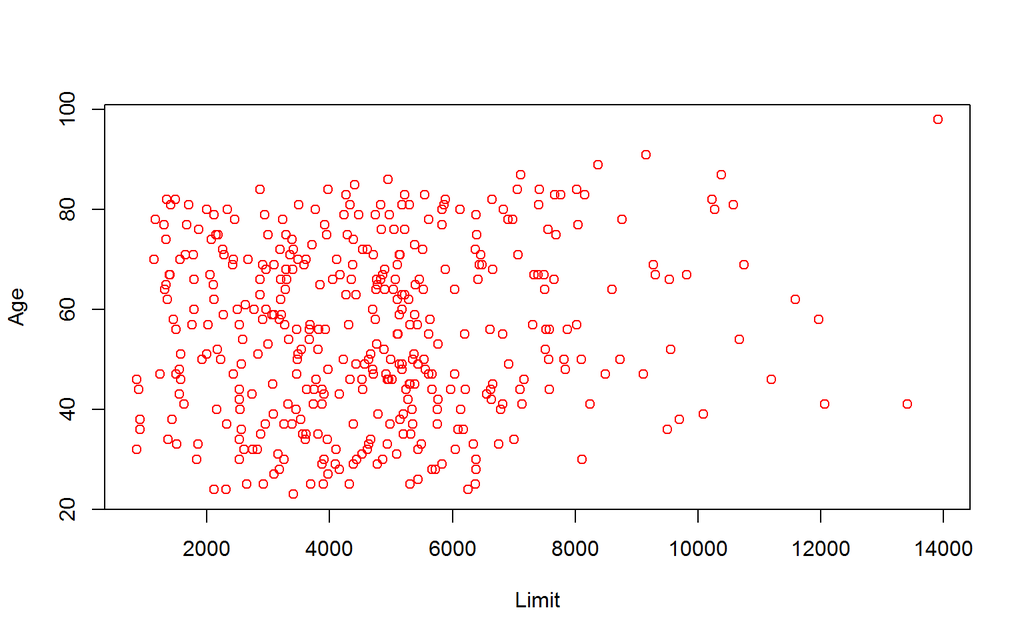

```r
plot(Credit$Limit, Credit$Age, xlab = "Limit", ylab = "Age", col="red")
```

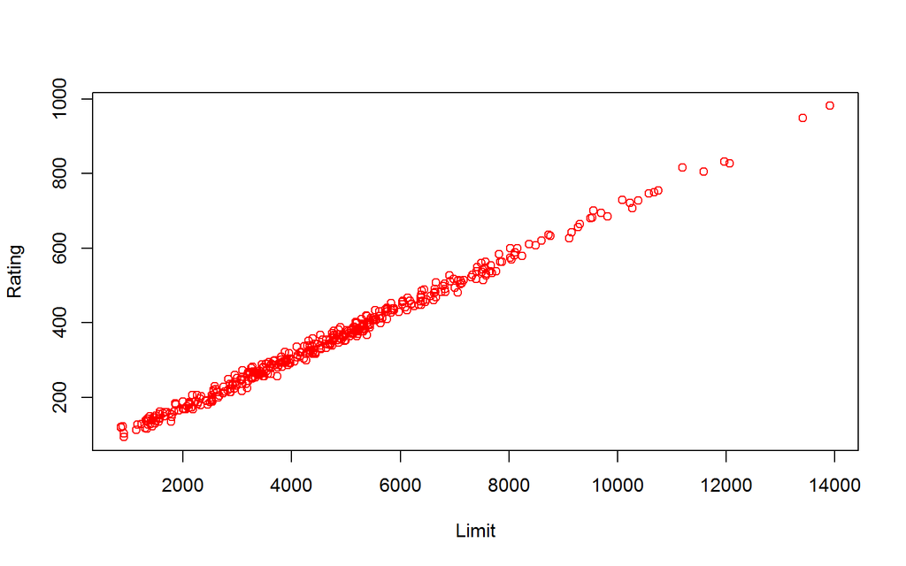

```r
plot(Credit$Limit, Credit$Rating, xlab = "Limit", ylab = "Rating", col="red")
```

Se observa que Limit y Rating están altamente correlacionadas mientras que Limit y Age no lo están

Con la función `plot` usando como argumento el dataframe, se pueden ver todas las correlaciones a pares

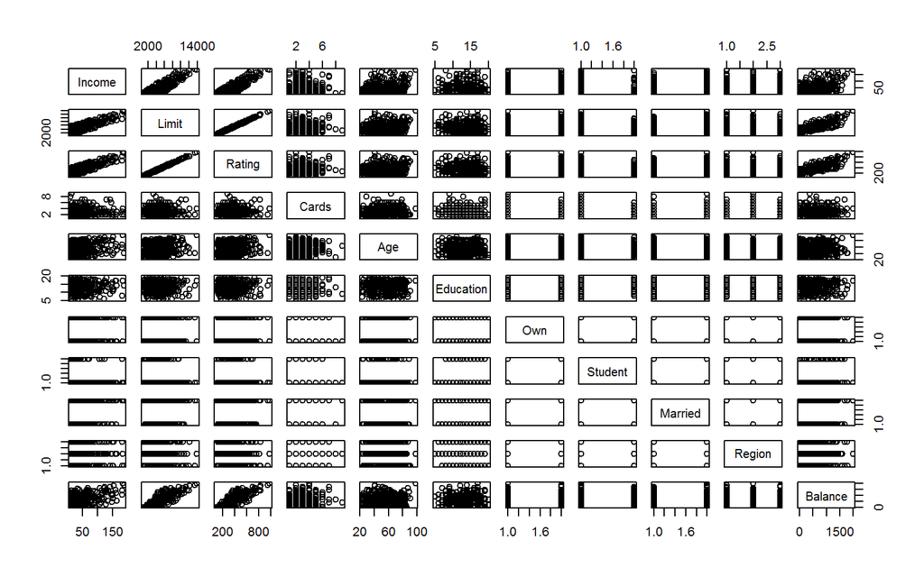

```r
plot(Credit)
```

Reporducimos la tabla 3.11

```r
model_1 <- lm(data = Credit, formula = Balance ~ Age + Limit)
model_2 <- lm(data = Credit, formula = Balance ~ Rating + Limit)
export_summs(model_1,model_2, digits = 3)
```

|  | Model 1 | Model 2 |
| --- | --- | --- |
| (Intercept) | -173.411 *** | -377.537 *** |
|  | (43.828) | (45.254) |
| Age | -2.291 *** |  |
|  | (0.672) |  |
| Limit | 0.173 *** | 0.025 |
|  | (0.005) | (0.064) |
| Rating |  | 2.202 * |
|  |  | (0.952) |
| N | 400 | 400 |
| R2 | 0.750 | 0.746 |
| *** p < 0.001; ** p < 0.01; * p < 0.05. |  |  |

## Variables cualitativas

Vamos a introducir una variable cualitativa en el modelo, copiamos el data frame de Credit en uno nuevo, para poder realizar modificaciones

```r
credito <- ISLR2::Credit
```

Creamos una variable binaria para indicar si la persona es propietaria de su vivienda o no, asignando un 1 en el caso que sea propietario y cero en caso contrario. Lo hacemos usando la función `ifelse`

```r
credito$propietario <- ifelse(credito$Own == "Yes", 1, 0)
```

Ahora estimamos el modelo con la variable cualitativa y replicamos la tabla 3.7 del libro

```r
model_3 <- lm(data = credito, formula = Balance ~ propietario)
summ(model_3)
```

| Observations | 400 |
| --- | --- |
| Dependent variable | Balance |
| Type | OLS linear regression |

| F(1,398) | 0.18 |
| --- | --- |
| R² | 0.00 |
| Adj. R² | -0.00 |

|  | Est. | S.E. | t val. | p |
| --- | --- | --- | --- | --- |
| (Intercept) | 509.80 | 33.13 | 15.39 | 0.00 |
| propietario | 19.73 | 46.05 | 0.43 | 0.67 |

Standard errors: OLS

Como se menciona en la página 84 del libro, el intercepto representa en esta caso el balance promedio de los no-propietarios, y $\beta_1$ la diferencia entre el balance de un propietario y un no-propietario. Específicamente un no-popietario tiene un balance de 509,80 dólares y un propietario 19,73 dólares más, 509,8+19,73=529,53.

Ahora vamos a replicar otro ejemplo, en este caso, el ejemplo 7.1 del libro de Wooldridge.

Inspeccionamos los datos

```r
head(wooldridge::wage1)
```

| wage | educ | exper | tenure | nonwhite | female | married | numdep | smsa | northcen | south | west | construc | ndurman | trcommpu | trade | services | profserv | profocc | clerocc | servocc | lwage | expersq | tenursq |
| --- | --- | --- | --- | --- | --- | --- | --- | --- | --- | --- | --- | --- | --- | --- | --- | --- | --- | --- | --- | --- | --- | --- | --- |
| 3.1 | 11 | 2 | 0 | 0 | 1 | 0 | 2 | 1 | 0 | 0 | 1 | 0 | 0 | 0 | 0 | 0 | 0 | 0 | 0 | 0 | 1.13 | 4 | 0 |
| 3.24 | 12 | 22 | 2 | 0 | 1 | 1 | 3 | 1 | 0 | 0 | 1 | 0 | 0 | 0 | 0 | 1 | 0 | 0 | 0 | 1 | 1.18 | 484 | 4 |
| 3 | 11 | 2 | 0 | 0 | 0 | 0 | 2 | 0 | 0 | 0 | 1 | 0 | 0 | 0 | 1 | 0 | 0 | 0 | 0 | 0 | 1.1 | 4 | 0 |
| 6 | 8 | 44 | 28 | 0 | 0 | 1 | 0 | 1 | 0 | 0 | 1 | 0 | 0 | 0 | 0 | 0 | 0 | 0 | 1 | 0 | 1.79 | 1936 | 784 |
| 5.3 | 12 | 7 | 2 | 0 | 0 | 1 | 1 | 0 | 0 | 0 | 1 | 0 | 0 | 0 | 0 | 0 | 0 | 0 | 0 | 0 | 1.67 | 49 | 4 |
| 8.75 | 16 | 9 | 8 | 0 | 0 | 1 | 0 | 1 | 0 | 0 | 1 | 0 | 0 | 0 | 0 | 0 | 1 | 1 | 0 | 0 | 2.17 | 81 | 64 |

Replicamos el ejemplo

```r
model_04 <- lm(data = wage1, formula = wage ~ female + educ + exper + tenure)
summ(model_04, digits = 3)
```

| Observations | 526 |
| --- | --- |
| Dependent variable | wage |
| Type | OLS linear regression |

| F(4,521) | 74.398 |
| --- | --- |
| R² | 0.364 |
| Adj. R² | 0.359 |

|  | Est. | S.E. | t val. | p |
| --- | --- | --- | --- | --- |
| (Intercept) | -1.568 | 0.725 | -2.164 | 0.031 |
| female | -1.811 | 0.265 | -6.838 | 0.000 |
| educ | 0.572 | 0.049 | 11.584 | 0.000 |
| exper | 0.025 | 0.012 | 2.195 | 0.029 |
| tenure | 0.141 | 0.021 | 6.663 | 0.000 |

Standard errors: OLS

Como menciona el libro en el ejemplo (página 229), el coeficiente de la variable *female* indica la diferencia en el salario promedio entre un hombre y una mujer con el mismo nivel de educación (*educ*), experiencia labora (*exper*) y antiguedad en el trabajo (*tenure*). Al ser negativo, indica que en esta muestra las mujeres tienen un salario medio inferior al de los hombres controlando por las características arriba mencionadas.

## Interacciones

Vamos a replicar el ejemplo de la página 88 del libro de Statistical Learning, donde se introducen las interacciones entre variables del modelo.

Vamos a trabajar con la base de datos *Advertising*. Si aún no la han descargado, la pueden encontrar [acá](https://www.statlearning.com/resources-second-edition) en la sección de Data Sets.

Accedemos a los datos

```r
Advertising <- read.csv("~/Predictiva/Intro/Data/Advertising.csv")
```

Replicamos la tabla 3.4

```r
modelo_publicidad <- lm(data = Advertising, formula = sales ~ TV + radio + newspaper)
summ(modelo_publicidad, digits = 4)
```

| Observations | 200 |
| --- | --- |
| Dependent variable | sales |
| Type | OLS linear regression |

| F(3,196) | 570.2707 |
| --- | --- |
| R² | 0.8972 |
| Adj. R² | 0.8956 |

|  | Est. | S.E. | t val. | p |
| --- | --- | --- | --- | --- |
| (Intercept) | 2.9389 | 0.3119 | 9.4223 | 0.0000 |
| TV | 0.0458 | 0.0014 | 32.8086 | 0.0000 |
| radio | 0.1885 | 0.0086 | 21.8935 | 0.0000 |
| newspaper | -0.0010 | 0.0059 | -0.1767 | 0.8599 |

Standard errors: OLS

Observamos que la variable *newspaper* no es estadísticamente significativa a nivel individual, así que procedemos a eliminarla y reestimar el modelo

```r
modelo_publicidad2 <- lm(data = Advertising, formula = sales ~ TV + radio)
summ(modelo_publicidad2, digits = 4)
```

| Observations | 200 |
| --- | --- |
| Dependent variable | sales |
| Type | OLS linear regression |

| F(2,197) | 859.6177 |
| --- | --- |
| R² | 0.8972 |
| Adj. R² | 0.8962 |

|  | Est. | S.E. | t val. | p |
| --- | --- | --- | --- | --- |
| (Intercept) | 2.9211 | 0.2945 | 9.9192 | 0.0000 |
| TV | 0.0458 | 0.0014 | 32.9087 | 0.0000 |
| radio | 0.1880 | 0.0080 | 23.3824 | 0.0000 |

Standard errors: OLS

Vamos a introducir una interacción entre las variables *TV* y *radio* y replicamos la tabla 3.9 del libro

```r
modelo_publicidad3 <- lm(data = Advertising, formula = sales ~ TV + radio + TV*radio)
summ(modelo_publicidad3, digits = 4)
```

| Observations | 200 |
| --- | --- |
| Dependent variable | sales |
| Type | OLS linear regression |

| F(3,196) | 1963.0569 |
| --- | --- |
| R² | 0.9678 |
| Adj. R² | 0.9673 |

|  | Est. | S.E. | t val. | p |
| --- | --- | --- | --- | --- |
| (Intercept) | 6.7502 | 0.2479 | 27.2328 | 0.0000 |
| TV | 0.0191 | 0.0015 | 12.6990 | 0.0000 |
| radio | 0.0289 | 0.0089 | 3.2408 | 0.0014 |
| TV:radio | 0.0011 | 0.0001 | 20.7266 | 0.0000 |

Standard errors: OLS

El parámetro asociado a la interacción indica el incremento en la efectividad de la publicidad en televisión asociado a un incremento de una unidad en el gasto de publicidad de la radio.

### Interacciones con variables binarias

Ahora vamos a replicar el ejemplo de la página 90 del libro de Statistical Learning, donde la interacción se realiza con una variable binaria. Volvemos a utilizar la base de datos Credit, pero ahora vamos a estimar un modelo en el que las variables independientes son el nivel de ingreso y una variable cualitativa que indica si la persona es estudiante o no.

Vamos a fijarnos en el tipo de variables de la base de datos Credit

```r
str(Credit)
```

```
## 'data.frame':    400 obs. of  11 variables:
##  $ Income   : num  14.9 106 104.6 148.9 55.9 ...
##  $ Limit    : num  3606 6645 7075 9504 4897 ...
##  $ Rating   : num  283 483 514 681 357 569 259 512 266 491 ...
##  $ Cards    : num  2 3 4 3 2 4 2 2 5 3 ...
##  $ Age      : num  34 82 71 36 68 77 37 87 66 41 ...
##  $ Education: num  11 15 11 11 16 10 12 9 13 19 ...
##  $ Own      : Factor w/ 2 levels "No","Yes": 1 2 1 2 1 1 2 1 2 2 ...
##  $ Student  : Factor w/ 2 levels "No","Yes": 1 2 1 1 1 1 1 1 1 2 ...
##  $ Married  : Factor w/ 2 levels "No","Yes": 2 2 1 1 2 1 1 1 1 2 ...
##  $ Region   : Factor w/ 3 levels "East","South",..: 2 3 3 3 2 2 1 3 2 1 ...
##  $ Balance  : num  333 903 580 964 331 ...
```

Observamos que la variable *Student* es un **factor**. En R se emplea el tipo factor para representar variables catergóricas (sexo, estado civil, código postal, cargo, etc.). Existen variables categóricas las cuales poseen *niveles*, por ejemplo si nos referimos a tamaños, mediano es mayor a pequeño y estos dos a su vez están por debajo de grande.

El tipo factor permite que podamos realizar análisis estadísticos sobre variables categóricas tengan o no niveles u ordenaciones por jerarquía.

Si una variable está definida como un factor, no hace falta realizar la transformación que hemos hecho anteriormente con la función `ifelse`

Estimamos el modelo correspondiente a la ecuación 3.34 de la página 90 del libro, que no es más que un modelo con una variable cualitativa como el de la sección anterior

```r
model_b <- lm(data = Credit, formula = Balance ~ Income + Student)
summ(model_b, digits = 4)
```

| Observations | 400 |
| --- | --- |
| Dependent variable | Balance |
| Type | OLS linear regression |

| F(2,397) | 76.2249 |
| --- | --- |
| R² | 0.2775 |
| Adj. R² | 0.2738 |

|  | Est. | S.E. | t val. | p |
| --- | --- | --- | --- | --- |
| (Intercept) | 211.1430 | 32.4572 | 6.5053 | 0.0000 |
| Income | 5.9843 | 0.5566 | 10.7511 | 0.0000 |
| StudentYes | 382.6705 | 65.3108 | 5.8592 | 0.0000 |

Standard errors: OLS

Vamos a replicar el grafíco de la izquierda de la figura 3.7, usando la función `ggPredict` de la librería `ggiraphExtra`.

Cargamos la librería y hacemos el gráfico, usando como argumentos el modelo estimado, `se`que nos pregunta si queremos que nos grafique el intervalo de confianza, e `interactive` para que el gráfico sea interactivo

```r
pacman::p_load(ggiraphExtra)
ggPredict(model_b, se = FALSE, interactive = TRUE)
```

[interactive chart not shown]

Observamos un modelo estándar de variables cualitativas en el cual hay un intercepto distinto en el caso de si se es estudiante o no, y pendientes iguales.

A continuación, introducimos una interacción entre el ingreso y la variable binaria *Student*, representado en la ecuación 3.35 de la página 90.

```r
model_b2 <- lm(data = Credit, formula = Balance ~ Income + Student + Income*Student)
summ(model_b2, digits = 4)
```

| Observations | 400 |
| --- | --- |
| Dependent variable | Balance |
| Type | OLS linear regression |

| F(3,396) | 51.3037 |
| --- | --- |
| R² | 0.2799 |
| Adj. R² | 0.2744 |

|  | Est. | S.E. | t val. | p |
| --- | --- | --- | --- | --- |
| (Intercept) | 200.6232 | 33.6984 | 5.9535 | 0.0000 |
| Income | 6.2182 | 0.5921 | 10.5020 | 0.0000 |
| StudentYes | 476.6758 | 104.3512 | 4.5680 | 0.0000 |
| Income:StudentYes | -1.9992 | 1.7313 | -1.1547 | 0.2489 |

Standard errors: OLS

```r
ggPredict(model_b2, se = FALSE, interactive = TRUE)
```

[interactive chart not shown]

Observamos ahora como la interacción hace que las pendientes de la estimación para estudiantes y no-estudiantes ya no se sean paralelas, como el gráfico de la derecha de la figura 3.7

## Evaluación o diagnósis del modelo

En esta sección se muestra como basados en unos gráficos, se puede comprobar si el modelo estimado cumple con ciertas propiedades de partida del modelo lineal, como lo son la linealidad, la homocedasticidad, la autocorrelación de los residuos, la normalidad de los errores y la multicolinealidad.

Empezamos con el instrumental gráfico de R base, tomando como ejemplo el modelo estimado del gasto de publicidad con interacciones

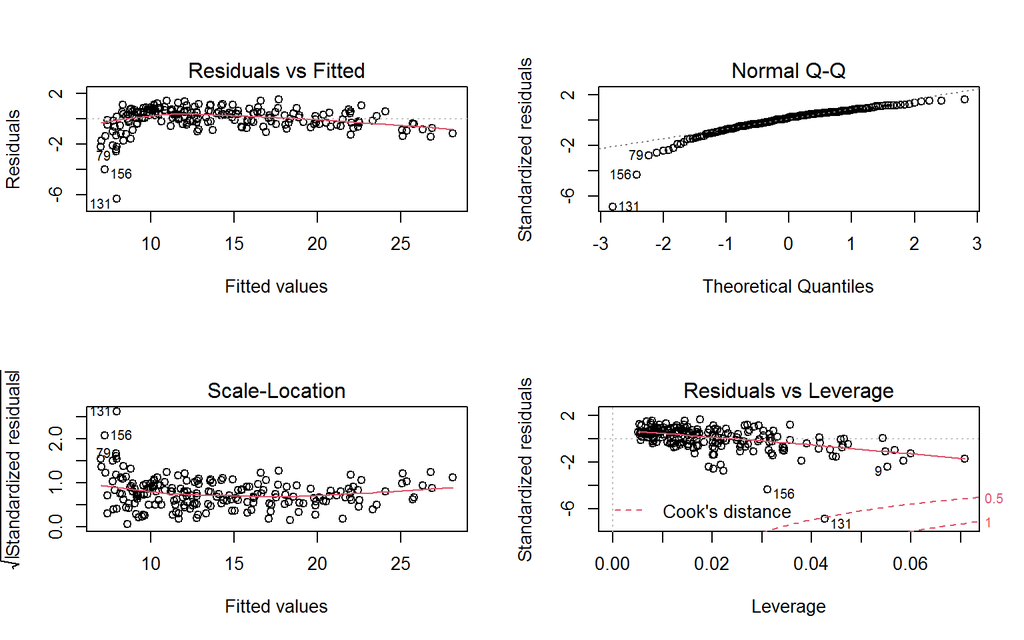

```r
oldpar <- par( mfrow=c(2,2))
plot(modelo_publicidad3)
```

```r
par(oldpar)
```

En el sentido de las agujas del reloj, el primer gráfico es un gráfico de residuos, en el cual se representan los residuos $u_i=y_i-\hat{y}_i$ vs. los valores estimados por el modelo $\hat{y}_i$. Si se cumple el supuesto de que existe una relación lineal entre la variable respuesta o dependiente y los regresores, el gráfico de dispersión no debería tener ningún patrón sistemático y la línea roja debería ser horizontal.

En el segundo gráfico es el QQ (cuantil-cuantil) Plot. Dicho gráfico lo que hace es comparar unos datos determinados, en este caso los residuos estandarizados, con donde deberían estar localizados dichos datos en una distribución normal. Si todos o la mayoría de los puntos están sobre la línea recta, entonces podemos afirmar que los residuos siguen una distribución normal.

En el tercer gráfico donde se representan la raíz cuadrada de los residuos estandarizados y los valores estimados por el modelo, el mismo se utiliza para detectar *heterocedasticidad*. Debemos observar si los residuos están igual de dispersos a medida que nos movemos de izquierda a derecha. De ser así la línea roja debería ser horizontal.

El último gráfico se usa para detectar problemas de valores atípicos (outliers) o valores influyentes (leverage). En el eje vertical tenemos los residuos estandarizados, sus valores nos indican que tan alejados están de la media. Si los residuos están muy alejados de la media (mayor a 3), tendremos valores atípicos.

Según estos gráficos podríamos decir el modelo presenta evidencia de no-linealidad, no-normalidad y presencia de atípicos.

Existe una librería que nos proporciona un gráfico más amigable, la librería `performance`

La instalamos y con la función `check_model` obtenemos un gráfico similar

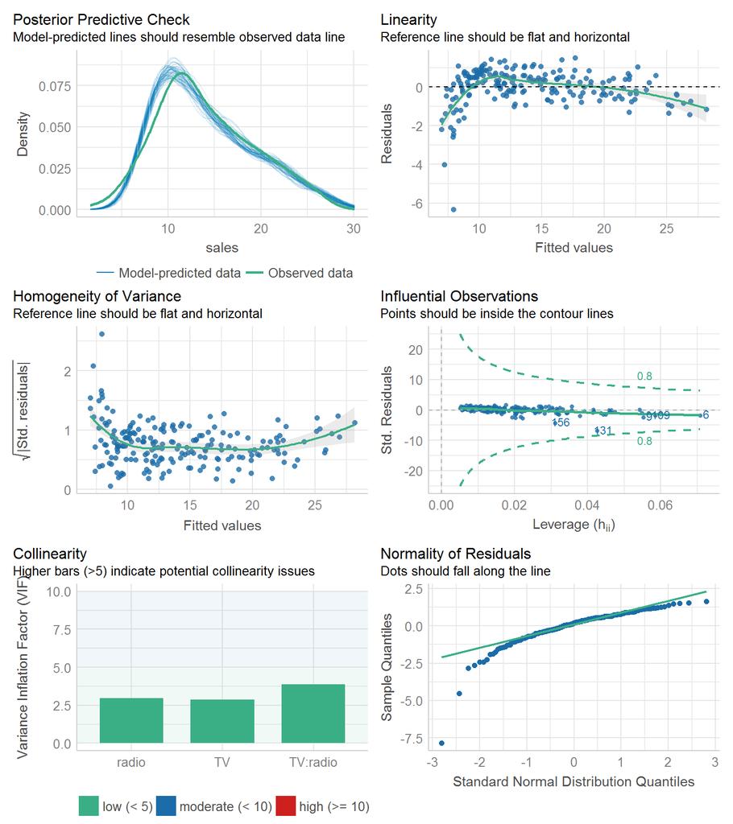

```r
pacman::p_load(performance)
check_model(modelo_publicidad3)
```

No usaremos el primero del conjunto de gráficos, por lo que lo obviamos. Observamos que son los mismos gráficos pero más claros y además en el subtítulo nos indica en que debemos fijarnos. Por ejemplo, vemos que con el gráfico anterior teníamos sospechas de valores atípicos, y en este se ve más claro que no es el caso.

Hay sub-gráfico que no analizamos anteriormente, y es el de colinariedad, que sirve para detectar problemas de multicolinealidad. En el mismo observamos unas barras que corresponden al *factor de inflación de la varianza*. Valores altos de estos son evidencia de multicolinealidad, explicamos en que consiste dicho factor.

Si revisamos la diapositiva 42 de la presentación de clase *"Regresión lineal múltiple: estimación"*, vemos que una manera de detectar multicolinealidad es realizar una regresión del regresor $i$ en función del resto de regresores, si el $R^2$ de dicha regresión es alto estamos en presencia de multicolinealidad. Si realizamos dichas regresiones para cada variable independiente y obtenemos el $R^2$ correspondiente, el factor de inflación de la varianza del regresor $j$ $\big(VIF(\hat{\beta}_j)\big)$ viene dado por:
$$VIF(\hat{\beta}_j)=\frac{1}{1-R^2_{x_j|x_{-j}}}$$

Si el $R^2$ de la regresión es alto, el $VIF(\hat{\beta}_j)$ es alto, por lo que existe evidencia de multicolinealidad.

Se denomina factor de inflación de la varianza, por la definición de la varianza de los betas en el caso de una regresión múltiple. Recordar que la desviación típica de $\beta_1$ en el caso de la regresión simple y en ausencia de heterocedasticidad viene dado por (diapositiva 28 de la presentación de clase Regresión lineal simple: Heterocedasticidad y Homocedasticidad):
$$VAR(\beta_1)=\frac{\sigma_u^2}{\sum^n_{i=1}(x_i-\bar{x})^2}$$

No se ha hecho en clase, pero es posible demostrar (ver ecuación 3.51, página 95 del libro de Wooldridge) que en el caso de la regresión lineal múltiple, la varianza del beta correspondiente al regresor $j$ es igual a:

$$VAR(\beta_j)=\frac{\sigma_u^2}{\sum^n_{i=1}\bigg(x_i-\bar{x}\bigg)^2\bigg(1-R^2_{x_j|x_{-j}}\bigg)}=\frac{\sigma_u^2}{\sum^n_{i=1}(x_i-\bar{x})^2}\frac{1}{\bigg(1-R^2_{x_j|x_{-j}}\bigg)}$$

El VFI lo que hace es "inflar" la varianza de $\beta_j$.

Hay quienes indican que un VFI superior a 10 señala un problema de multicolinealidad, pero este es un límite arbitrario y varía según el analista, libro de texto, informe, etc.

# Laboratorio 7

El objetivo de este laboratorio es obtener las predicciones de un modelo lineal y el intervalo de confianza de la predicción. Usaremos el ejemplo del libro de Stock y Watson

```r
pacman::p_load(haven,jtools)
```

Cargamos los datos

```r
caschool <- read_dta("Data/caschool.dta")
head(caschool)
```

| observat | dist_cod | county | district | gr_span | enrl_tot | teachers | calw_pct | meal_pct | computer | testscr | comp_stu | expn_stu | str | avginc | el_pct | read_scr | math_scr |
| --- | --- | --- | --- | --- | --- | --- | --- | --- | --- | --- | --- | --- | --- | --- | --- | --- | --- |
| 1 | 7.51e+04 | Alameda | Sunol Glen Unified | KK-08 | 195 | 10.9 | 0.51 | 2.04 | 67 | 691 | 0.344 | 6.38e+03 | 17.9 | 22.7 | 0 | 692 | 690 |
| 2 | 6.15e+04 | Butte | Manzanita Elementary | KK-08 | 240 | 11.1 | 15.4 | 47.9 | 101 | 661 | 0.421 | 5.1e+03 | 21.5 | 9.82 | 4.58 | 660 | 662 |
| 3 | 6.15e+04 | Butte | Thermalito Union Elementary | KK-08 | 1.55e+03 | 82.9 | 55 | 76.3 | 169 | 644 | 0.109 | 5.5e+03 | 18.7 | 8.98 | 30 | 636 | 651 |
| 4 | 6.15e+04 | Butte | Golden Feather Union Elementary | KK-08 | 243 | 14 | 36.5 | 77 | 85 | 648 | 0.35 | 7.1e+03 | 17.4 | 8.98 | 0 | 652 | 644 |
| 5 | 6.15e+04 | Butte | Palermo Union Elementary | KK-08 | 1.34e+03 | 71.5 | 33.1 | 78.4 | 171 | 641 | 0.128 | 5.24e+03 | 18.7 | 9.08 | 13.9 | 642 | 640 |
| 6 | 6.2e+04 | Fresno | Burrel Union Elementary | KK-08 | 137 | 6.4 | 12.3 | 87 | 25 | 606 | 0.182 | 5.58e+03 | 21.4 | 10.4 | 12.4 | 606 | 605 |

Estimamos el modelo con todos los datos (comparar con tabla 7.1 del libro)

```r
modelo_full <- lm(data = caschool, formula = testscr ~ str + el_pct + meal_pct + calw_pct)
summ(modelo_full, robust = "HC1", digits = 3)
```

| Observations | 420 |
| --- | --- |
| Dependent variable | testscr |
| Type | OLS linear regression |

| F(4,415) | 357.054 |
| --- | --- |
| R² | 0.775 |
| Adj. R² | 0.773 |

|  | Est. | S.E. | t val. | p |
| --- | --- | --- | --- | --- |
| (Intercept) | 700.392 | 5.537 | 126.483 | 0.000 |
| str | -1.014 | 0.269 | -3.773 | 0.000 |
| el_pct | -0.130 | 0.036 | -3.581 | 0.000 |
| meal_pct | -0.529 | 0.038 | -13.868 | 0.000 |
| calw_pct | -0.048 | 0.059 | -0.816 | 0.415 |

Standard errors: Robust, type = HC1

Dividimos la muestra, dejamos algunas observaciones fuera, para luego predecir con las caracteristicas de estas observaciones. Determinamos de manera aleatoria que elementos sacamos de la muestra, 20 en nuestro caso.

```r
set.seed(1234)
filas <- sample(x = rownames(caschool),20)
filas
```

```
##  [1] "284" "336" "406" "101" "111" "393" "133" "400" "388" "98"  "103" "214"
## [13] "90"  "326" "79"  "372" "270" "382" "184" "62"
```

Dividimos la muestra en dos

```r
caschool_train <- caschool[-as.numeric(filas),]
caschool_test <- caschool[as.numeric(filas),]
```

Estimamos con los datos restantes (entrenamiento)

```r
modelo_train <- lm(data = caschool_train, formula = testscr ~ str + el_pct + meal_pct + calw_pct)
summ(modelo_train, robust = "HC1", digits = 3)
```

| Observations | 400 |
| --- | --- |
| Dependent variable | testscr |
| Type | OLS linear regression |

| F(4,395) | 335.662 |
| --- | --- |
| R² | 0.773 |
| Adj. R² | 0.770 |

|  | Est. | S.E. | t val. | p |
| --- | --- | --- | --- | --- |
| (Intercept) | 700.866 | 5.735 | 122.209 | 0.000 |
| str | -1.045 | 0.278 | -3.762 | 0.000 |
| el_pct | -0.138 | 0.037 | -3.670 | 0.000 |
| meal_pct | -0.519 | 0.040 | -12.944 | 0.000 |
| calw_pct | -0.063 | 0.062 | -1.013 | 0.311 |

Standard errors: Robust, type = HC1

Predecimos los valores de las observaciones que hemos dejado fuera (prueba), construyendo un intervalo del 95% de confianza

```r
prediccion <-  predict(object = modelo_train, newdata = caschool_test, interval = "prediction", level = 0.95)
prediccion
```

```
##         fit      lwr      upr
## 1  666.5762 648.6275 684.5250
## 2  665.4875 647.5527 683.4223
## 3  680.6580 662.6717 698.6443
## 4  643.7414 625.7704 661.7125
## 5  632.8713 614.8827 650.8600
## 6  675.0748 657.1307 693.0189
## 7  645.1979 627.2792 663.1165
## 8  670.2559 652.2409 688.2708
## 9  675.2279 657.2060 693.2499
## 10 638.6471 620.6735 656.6206
## 11 650.1968 632.1952 668.1984
## 12 663.6118 645.6646 681.5590
## 13 630.6395 612.4075 648.8716
## 14 674.8212 656.8517 692.7907
## 15 649.0691 630.9617 667.1765
## 16 678.3952 660.4335 696.3569
## 17 680.2678 662.2603 698.2753
## 18 673.2501 655.2947 691.2054
## 19 653.1579 635.2227 671.0930
## 20 630.0947 611.6587 648.5306
```

Construimos una tabla con el valor real de la variable dependiente

```r
prediccion2 <-  cbind(prediccion, caschool_test$testscr)
prediccion2
```

```
##         fit      lwr      upr
## 1  666.5762 648.6275 684.5250 663.50
## 2  665.4875 647.5527 683.4223 669.80
## 3  680.6580 662.6717 698.6443 694.25
## 4  643.7414 625.7704 661.7125 638.55
## 5  632.8713 614.8827 650.8600 640.10
## 6  675.0748 657.1307 693.0189 683.40
## 7  645.1979 627.2792 663.1165 643.70
## 8  670.2559 652.2409 688.2708 687.55
## 9  675.2279 657.2060 693.2499 682.15
## 10 638.6471 620.6735 656.6206 638.30
## 11 650.1968 632.1952 668.1984 639.25
## 12 663.6118 645.6646 681.5590 654.85
## 13 630.6395 612.4075 648.8716 637.00
## 14 674.8212 656.8517 692.7907 668.60
## 15 649.0691 630.9617 667.1765 635.45
## 16 678.3952 660.4335 696.3569 677.25
## 17 680.2678 662.2603 698.2753 661.90
## 18 673.2501 655.2947 691.2054 680.05
## 19 653.1579 635.2227 671.0930 651.40
## 20 630.0947 611.6587 648.5306 633.05
```

colocamos un nombre a la ultima columna

```r
colnames(prediccion2)
```

```
## [1] "fit" "lwr" "upr" ""
```

```r
colnames(prediccion2)[4] <- "real"

prediccion2
```

```
##         fit      lwr      upr   real
## 1  666.5762 648.6275 684.5250 663.50
## 2  665.4875 647.5527 683.4223 669.80
## 3  680.6580 662.6717 698.6443 694.25
## 4  643.7414 625.7704 661.7125 638.55
## 5  632.8713 614.8827 650.8600 640.10
## 6  675.0748 657.1307 693.0189 683.40
## 7  645.1979 627.2792 663.1165 643.70
## 8  670.2559 652.2409 688.2708 687.55
## 9  675.2279 657.2060 693.2499 682.15
## 10 638.6471 620.6735 656.6206 638.30
## 11 650.1968 632.1952 668.1984 639.25
## 12 663.6118 645.6646 681.5590 654.85
## 13 630.6395 612.4075 648.8716 637.00
## 14 674.8212 656.8517 692.7907 668.60
## 15 649.0691 630.9617 667.1765 635.45
## 16 678.3952 660.4335 696.3569 677.25
## 17 680.2678 662.2603 698.2753 661.90
## 18 673.2501 655.2947 691.2054 680.05
## 19 653.1579 635.2227 671.0930 651.40
## 20 630.0947 611.6587 648.5306 633.05
```